# Plotting a phylogeny in

### 4.Multiple plots combined in layout

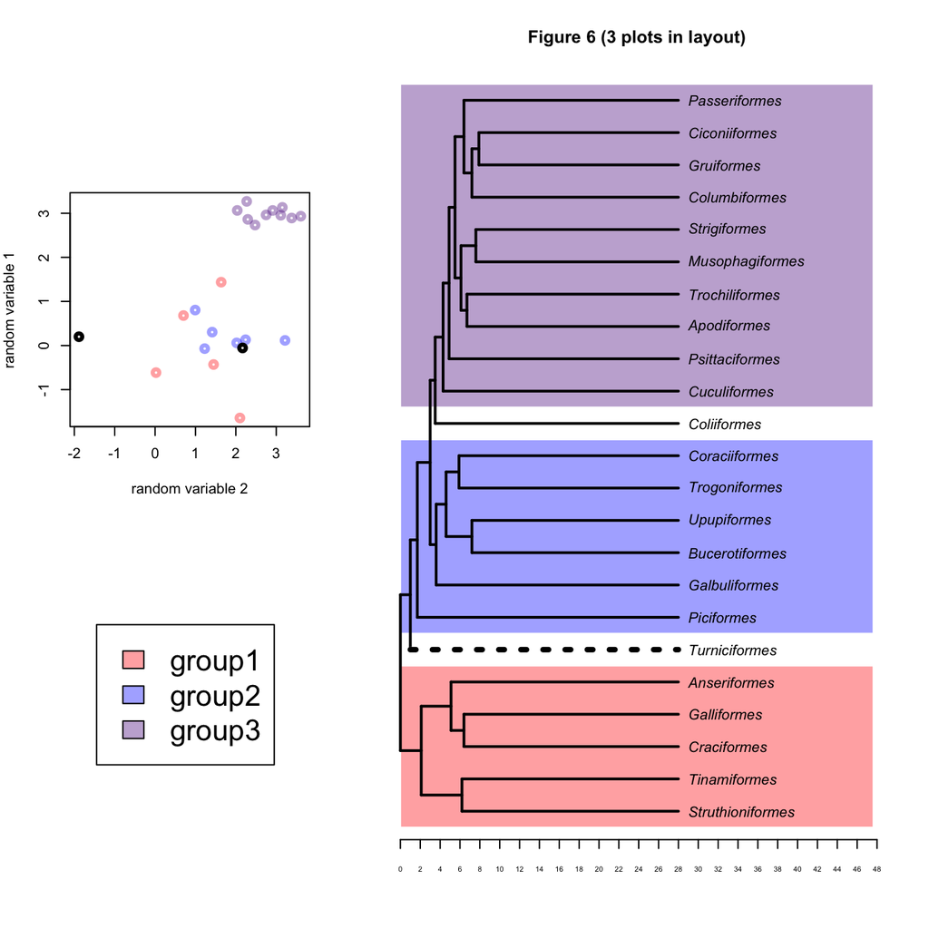

```r
#Setup layout as a 3 X 3 matrix with 3 regions (region 1 for the phylo tree, 2 for a x/y scatter and 3 for legend)
m = matrix(c(2,1,1,2,1,1,3,1,1), 3, 3, byrow = TRUE)
layout(m)

#Save plot.phylo parameters, without plotting yet
phylo = plot.phylo(bird.orders, edge.width = 2, label.offset = 1, plot = F, cex = 1)

#REGION 1: add boxes based on the y axis coordinates, the x-axis coord. are based on the phylogeny, and your groups of interest
rect(phylo$x.lim[1],0.5,phylo$x.lim[2],5.5,col = colors[1],border = F) #group 1
rect(phylo$x.lim[1],6.5,phylo$x.lim[2],12.5,col = colors[2], border = F) #group 2
rect(phylo$x.lim[1],13.5,phylo$x.lim[2],23.5, col = colors[3],border = F) #group 3

#Add phylogeny on top of rectangles
par(new = T)
phylo = plot.phylo(bird.orders, edge.width = 2, label.offset = 1, cex = 1, main = "Figure 6 (3 plots in layout)")

#Add an x axis that looks decent
axis(1,at =seq(from = 0, to = round(phylo$x.lim[2]), by = 2),cex.axis = 0.5)

#Make the segment for Turniciformes dashed (find out the x/y coordinates of the segment, color it white, then dashed red on top)
segments(1,6,28,6,col = "white", lwd = 4, lty = 1)
segments(1,6,28,6,col = "black", lwd = 4, lty = 3)

#REGION 2: set up some wider margins for region # 2 of layout
par(mar = c(11,4,11,0))

#Set up some fake data (say fake PCA data) for the 3 groups
pca = cbind(c(rnorm(6,mean=0,sd =1), rnorm(7,mean=2,sd =0.5),rnorm(10,mean=3,sd =0.5)),c(rnorm(6,mean=0,sd =1), rnorm(7,mean=0,sd =0.3),rnorm(10,mean=3,sd =0.2)))
rownames(pca) = bird.orders$tip.label

#Colors scheme according to boxes in phylo tree (5 red,1 black, 6 blue, 1 black, 10 purple)
colors_according_to_tree = c(rep(colors[1],5),"black",rep(colors[2],6),"black",rep(colors[3],10))

#Add another x/y scatter plot in region # 2 of layout
plot(pca,col = colors_according_to_tree,lwd =3,pch = 21, ylab = "random variable 1", xlab = "random variable 2")

#REGION 3: reset margins and empty plot
par(mar = c(5,4,4,2))
plot(1, type="n", xlab="", ylab="", xlim=c(0, 1), ylim=c(0, 1),xaxt="n",yaxt= "n", bty = "n")

#Add a legend here
legend(0.1,1.5,legend = c("group1","group2","group3"),fill = colors,xpd = T, cex = 2)
```

```r
#It looks good, save it with dev.print if you want
#dev.print(dev = pdf, "phylo_layout.pdf"); dev.off()
```

### 5.Adding coloured trait values

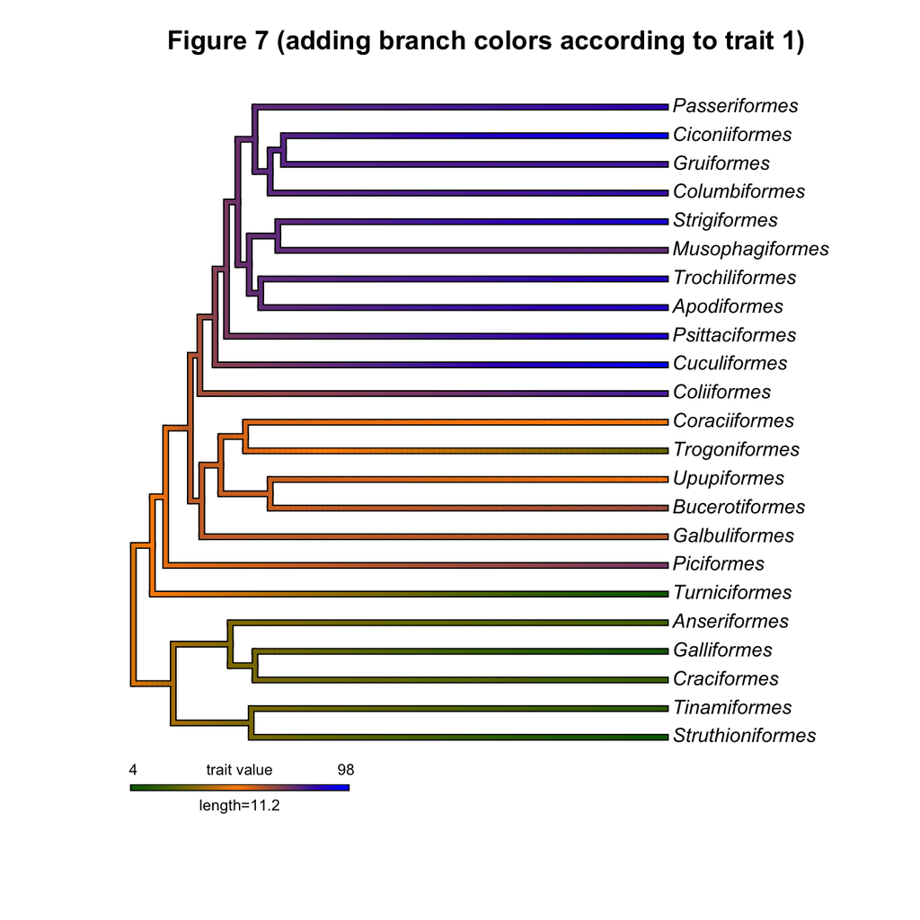

```r
###Add a trait value to the tree and plot it (trait object is based on the 3 colored grouping I did above)
trait1 = c(sample(c(0:25),6),c(sample(25:75,6)),sample(c(75:100),11))
names(trait1) = bird.orders$tip.label

#Use contMap from phytools
tree.trait <- contMap(bird.orders, trait1, plot = F)
tree.trait<-setMap(tree.trait, colors=c("darkgreen","darkorange","blue"))

#Carefull, we now plot using the plotting tool from phytools
plot.contMap(tree.trait,type = "phylogram",legend = 0.4*max(nodeHeights(bird.orders)), fsize = c(0.9, 0.7), lwd=3,mar = c(3,4,3,2))

#Add a title manually to plot.contMap
title("Figure 7 (adding branch colors according to trait 1)",xpd = T)
```

### 6.Adding pie charts + tip colors

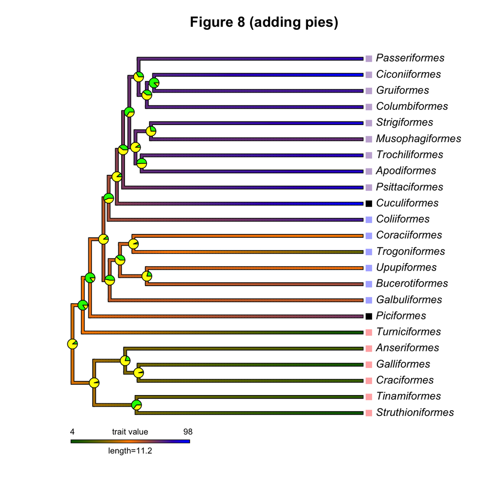

```r
#Add node labels (pie charts could be based on a genetic structuring analysis, or another trait value)
#You need a matrix defining your pies that can be generated as such:
pies = matrix(0,nrow =bird.orders$Nnode,ncol=2)
for(i in 1:bird.orders$Nnode) {x = sample(seq(0,1,by = 0.001),1); pies[i,] = c(x,1-x)}

#Plot
plot.contMap(tree.trait, type = "phylogram", legend = 0.4*max(nodeHeights(bird.orders)), fsize = c(0.9, 0.7), lwd=3, edge.width = 2, offset = 1,mar = c(2,4,3,2))
nodelabels(pie = pies, piecol = c("green","yellow"), cex = 0.6)

###Add tip labels colors based on trait1, but it could be on something entirely different.
tip.labels.col = c(rep(colors[1],6),"black",rep(colors[2],6),"black",rep(colors[3],10))
tiplabels(pch=15, cex=1.2, col= tip.labels.col,offset = 0.7)

#Add a title manually to plot.contMap
title("Figure 8 (adding pies)")
```

### 7.Adding a map

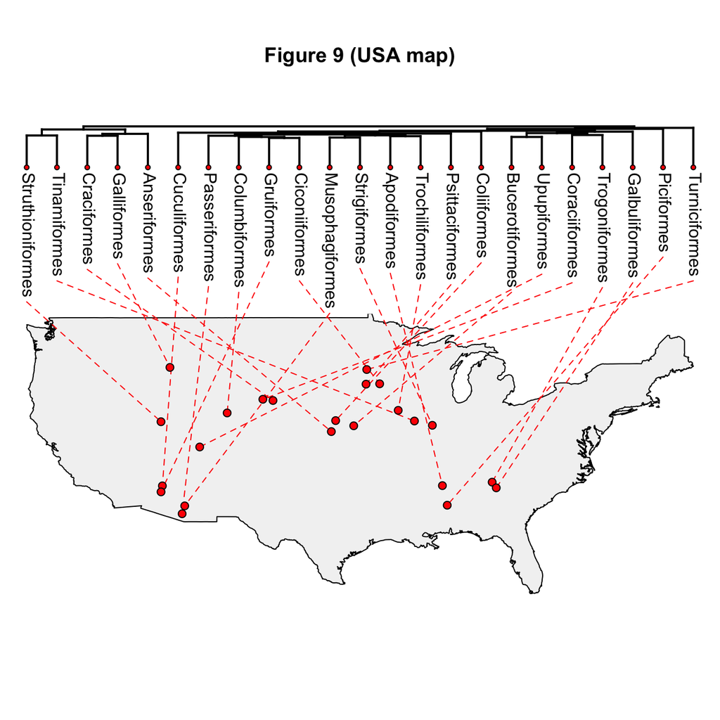

```r
#Matrix of random USA GPS coordinates
mat = matrix(c(sample(seq(from = 32, to = 45, by = 0.001),23),sample(seq(from = -120, to = -84, by = 0.001),23)),nrow = 23,ncol =2)
rownames(mat) = bird.orders$tip.label

###World mapping function (Here we are using a USA map, but this can be changes with the database option)
phylo.to.map(bird.orders,coords = mat, database = "usa")

#Add a title manually to plot.contMap
title("Figure 9 (USA map)",line = -3)
```

### 8.References

[^1]: Werner, G. D., Cornwell, W. K., Sprent, J. I., Kattge, J., & Kiers, E. T. (2014). A single evolutionary innovation drives the deep evolution of symbiotic N 2-fixation in angiosperms. Nature Communications, 5, 4087.
[^2]: Fiz-Palacios, Omar, Harald Schneider, Jochen Heinrichs, and Vincent Savolainen. “Diversification of land plants: insights from a family-level phylogenetic analysis.” BMC evolutionary biology 11, no. 1 (2011): 341.
[^3]: Christin, P. A., Spriggs, E., Osborne, C. P., Strömberg, C. A., Salamin, N., & Edwards, E. J. (2014). Molecular dating, evolutionary rates, and the age of the grasses. Systematic biology, 63(2), 153-165.
[^4]: Rambaut, A. (2007). FigTree, a graphical viewer of phylogenetic trees. See http://tree. bio. ed. ac. uk/software/figtree.
[^5]: Kumar, S., Stecher, G., & Tamura, K. (2016). MEGA7: molecular evolutionary genetics analysis version 7.0 for bigger datasets. Molecular biology and evolution, 33(7), 1870-1874.
[^6]: Revell, L. J. (2012) phytools: An R package for phylogenetic comparative biology (and other things). Methods Ecol. Evol., 3, 217-223.
[^7]: Revell, L. J. Phytools blog. http://blog.phytools.org/
[^8]: Paradis, E. (2012) Analysis of Phylogenetics and Evolution with R (Second Edition). New York: Springer.
[^9]: Wickham, Hadley. ggplot2: elegant graphics for data analysis. Springer, 2016.
[^10]: Wickham, Hadley, and Garrett Grolemund. R for data science: import, tidy, transform, visualize, and model data. " O’Reilly Media, Inc.“, 2016.
[^11]: R Core Team (2017). R: A language and environment for statistical computing. R Foundation for Statistical Computing, Vienna, Austria. URL https://www.R-project.org/.
[^12]: Aumer, B., Cetinkaya-Rundel, M., Bray, A., Loi, L., & Horton, N. J. (2014). R Markdown: Integrating a reproducible analysis tool into introductory statistics. arXiv preprint arXiv:1402.1894.
[^13]: Xie, Yihui. “knitr: A general-purpose package for dynamic report generation in R.” R package version 1.7 (2013): 1.